# Udacity_Enron_Dataset_Submission

## Identifying Fraud from the Enron Dataset

In this notebook, I will attempt to answer the 5 Free-Response Questions and perform some data visualisation and data wrangling of the Enron Dataset that will be useful to develop machine learning algorithm.

First, I will start the analysis by answering some questions about the data. Then, I will explore the available features by visualizing any correlations and singling out outliers. After that, I will create new features and add them to the dataset and explain how I selected them.

Algorithm selection and evaluation have been performed in the python script "poi_id.py". Finally, I will explain parameter tuning, validation using our training/testing data and talk about performance metrics to evaluate our results. Also, the performance of the best algorithm will be discussed.

### Question 1

In the year 2000, Enron was known as one of the largest energy companies in the United States, claiming nearly $111 billion in revenues. By 2002, it had collapsed into bankruptcy due to widespread corporate fraud. As a result of Federal investigation, there was a significant amount of typically confidential information entered into public record, including tens of thousands of emails and detailed financial data from top executives. This constitutes what is known as The Enron Email Corpus.

The goal of this project is to use the Enron Email Corpus Dataset and related financial data to build a Machine Learning Algorithm able to identify persons of interest (POI) in the Enron Scandal (i.e. detect the possibility of fraud)

The data has already been labelled for us to show whether an employee is a POI or not, therefore, we will be able to use supervised learning algorithms in constructing our POI identifier.

Machine Learning proves to be useful for such a project for at least two reasons:

- The Enron email corpus contains large amount of data: Trying to process data and recognize patterns using convetional tools would be impractical and inefficient.
- As we will see, the dataset contains lots of features and it is hard to select which features are more useful to predict whether a person is POI or not. This is the kind of problems where machine learning can prove to be insightful.

```python
# Importing packages
import pickle
import sklearn
import pandas as pd
from matplotlib import pyplot as plt

# Load the data as enron_dict
with open("final_project_dataset.pkl", "rb") as data_file:
    data_dict = pickle.load(data_file)

# Converting to pandas dataframe
enron_df = pd.DataFrame.from_records(list(data_dict.values()))

# set the index of df to be the employees series:
employees = pd.Series(list(data_dict.keys()))
enron_df.set_index(employees, inplace=True)

enron_df.head()
```

|  | salary | to_messages | deferral_payments | total_payments | loan_advances | bonus | email_address | restricted_stock_deferred | deferred_income | total_stock_value | ... | from_poi_to_this_person | exercised_stock_options | from_messages | other | from_this_person_to_poi | poi | long_term_incentive | shared_receipt_with_poi | restricted_stock | director_fees |
| --- | --- | --- | --- | --- | --- | --- | --- | --- | --- | --- | --- | --- | --- | --- | --- | --- | --- | --- | --- | --- | --- |
| METTS MARK | 365788 | 807 | NaN | 1061827 | NaN | 600000 | mark.metts@enron.com | NaN | NaN | 585062 | ... | 38 | NaN | 29 | 1740 | 1 | False | NaN | 702 | 585062 | NaN |
| BAXTER JOHN C | 267102 | NaN | 1295738 | 5634343 | NaN | 1200000 | NaN | NaN | -1386055 | 10623258 | ... | NaN | 6680544 | NaN | 2660303 | NaN | False | 1586055 | NaN | 3942714 | NaN |
| ELLIOTT STEVEN | 170941 | NaN | NaN | 211725 | NaN | 350000 | steven.elliott@enron.com | NaN | -400729 | 6678735 | ... | NaN | 4890344 | NaN | 12961 | NaN | False | NaN | NaN | 1788391 | NaN |
| CORDES WILLIAM R | NaN | 764 | NaN | NaN | NaN | NaN | bill.cordes@enron.com | NaN | NaN | 1038185 | ... | 10 | 651850 | 12 | NaN | 0 | False | NaN | 58 | 386335 | NaN |
| HANNON KEVIN P | 243293 | 1045 | NaN | 288682 | NaN | 1500000 | kevin.hannon@enron.com | NaN | -3117011 | 6391065 | ... | 32 | 5538001 | 32 | 11350 | 21 | True | 1617011 | 1035 | 853064 | NaN |

5 rows × 21 columns

```python
print("Number of data entries (people) in the Enron dataset : ",len(enron_df))
```

```
Number of data entries (people) in the Enron dataset :  146
```

```python
print("Number of Features in the Enron Dataset : ",len(enron_df.columns))
```

```
Number of Features in the Enron Dataset :  21
```

```python
# Counting the number of POIs and non-POIs in the given dataset
poi_count = enron_df.groupby('poi').size()
print("Total number of POI's in the dataset : ",poi_count.iloc[1])
print("Total number of non-POI's in the dataset : ",poi_count.iloc[0])
```

```
Total number of POI's in the dataset :  18
Total number of non-POI's in the dataset :  128
```

```python
enron_df.columns
```

```
Index(['salary', 'to_messages', 'deferral_payments', 'total_payments',
       'loan_advances', 'bonus', 'email_address', 'restricted_stock_deferred',
       'deferred_income', 'total_stock_value', 'expenses',
       'from_poi_to_this_person', 'exercised_stock_options', 'from_messages',
       'other', 'from_this_person_to_poi', 'poi', 'long_term_incentive',
       'shared_receipt_with_poi', 'restricted_stock', 'director_fees'],
      dtype='object')
```

The dataset is composed of 146 employees, 18 of which are persons of interest. Therefore, we can see that the dataset is unbalanced and we'll need to take this into account when we evaluate our model. Each employee is characterised by 21 features.

A script has been developed to check how many NaN values exist in the dataset, see function how_man_NaN.py:

```
import pandas as pd
import math
# Function to determine how many times NaN occurs in Enron Data set
def how_many_NaN(enron_df):
    dict_ = {}
    features = enron_df.columns
    for j in range(len(features)):
        dict_[features[j]] = 0
        for i in range(len(enron_df)):
            try:
                value = float(enron_df[features[j]].iloc[i])
                if math.isnan(value):
                    dict_[features[j]] += 1
            except ValueError:
                continue

    df = pd.DataFrame(dict_.items(), columns=['feature', 'NaNs'])
    df = df.sort_values('NaNs', ascending=False).set_index('feature')
    return df
```

The most concerning features having lots of NaN values are **Loan advances**, **Director fees** and **Restricted stock deferred** which have more than 85% of their values missing. At this point no data will be discarded until further Feature Selection to spot the most influential features.

#### Features sorted by amount of missing data

| Feature | NaNs |
| --- | --- |
| Loan advances | 142 |
| Director fees | 129 |
| Restricted stock deferred | 128 |
| Deferred payment | 107 |
| Deferred income | 97 |
| Long term incentive | 80 |
| Bonus | 64 |

Note that only the features with highest number of missing values are shown in the table. For the purpose of this analysis, I've decied to interpret the NaNs as equivalent to a zero.

```python
# Convert data into numeric values, option coerce is used to convert non numeric data to NaN
enron_df =  enron_df.apply(lambda x : pd.to_numeric(x, errors = 'coerce')).copy().fillna(0)
```

For the purpose of data visualisation, I've decided to plot the Bonus vs Salary:

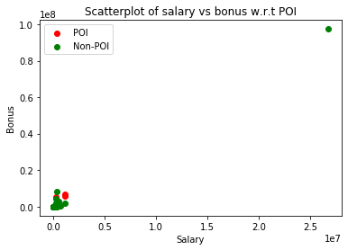

```python
# Plotting Salary vs bonus
plt.scatter(enron_df['salary'][enron_df['poi'] == True],enron_df['bonus'][enron_df['poi'] == True], color = 'r',
           label = 'POI')
plt.scatter(enron_df['salary'][enron_df['poi'] == False],enron_df['bonus'][enron_df['poi'] == False],color = 'g',
           label = 'Non-POI')

plt.xlabel("Salary")
plt.ylabel("Bonus")
plt.title("Scatterplot of salary vs bonus w.r.t POI")
plt.legend(loc='upper left')
plt.show()
```

It can be seen that one point is clearly an outlier has it has an abnormally high salary and bonus.

```python
# Singling out the non-POI employee having maximum salary
enron_df['salary'].idxmax()
```

```
'TOTAL'
```

Actually, the abnormal point refers to the total salary and bonus received by all employees so it makes sense to drop this data point.

From the supplied document enron61702insiderpay.pdf, a suspicious name was observed 'THE TRAVEL AGENCY IN THE PARK'. It was found out that Enron had the practice to make transactions with bogus companies to hide their profits/loss. I decided to remove this data point as most of its values are NaN except others and total-payments.

```
# Outlier removal
enron_df.drop('TOTAL', axis=0, inplace=True)
enron_df.drop('THE TRAVEL AGENCY IN THE PARK', axis=0, inplace=True)
```

### Question 2

During the development of machine learning algorithm, I decided to use all the features availables except the email address, therefore I have used 20 features. In addition, I've created three additional features

- bonus-to-salary_ratio: I suspect POIs will have a different bonus to salary ratio than a non-POI therefore it is worth including this feature in the analysis.
- from_poi_ratio: Fraction of messages received from POI among all messages received. A POI is more likely to receive lots of emails from other POIs therefore this ratio could be useful.
- to_poi_ratio: Fraction of messages send to POI among all messages send. Likewise, A POI is more likely to send lots of emails to other POIs therefore this ratio could be useful.

Therefore I've used a total of 23 features.

The given features can be divided into two types : financial features and email features.

- **17 financial features** : ['salary', 'bonus', 'long_term_incentive', 'bonus-to-salary_ratio', 'expenses','restricted_stock_deferred', 'restricted_stock', 'deferred_income','total_payments','other','shared_receipt_with_poi', 'loan_advances', 'director_fees', 'exercised_stock_options', 'deferral_payments', 'total_stock_value', 'restricted_stock']
- **6 Email features** : ['from_poi_ratio', 'to_poi_ratio', 'from_poi_to_this_person', 'from_this_person_to_poi', 'to_messages', 'from_messages']

```
# Feature engineering
feature_1 = pd.DataFrame(np.zeros((len(enron_df), 1)))
feature_1.set_index(employees, inplace=True)

feature_2 = pd.DataFrame(np.zeros((len(enron_df), 1)))
feature_2.set_index(employees, inplace=True)

feature_3 = pd.DataFrame(np.zeros((len(enron_df), 1)))
feature_3.set_index(employees, inplace=True)
# If statement to make sure division by zero are dealt with properly
for i in range(len(enron_df)):
    feature_1.iloc[i] = enron_df['bonus'].iloc[i] / enron_df['salary'].iloc[i] if \
        enron_df['salary'][i] != 0.0 else 0.0
    feature_2.iloc[i] = enron_df['from_poi_to_this_person'].iloc[i] / enron_df['to_messages'].iloc[i] if \
        enron_df['to_messages'][i] != 0.0 else 0.0
    feature_3.iloc[i] = enron_df['from_this_person_to_poi'][i] / enron_df['from_messages'].iloc[i] if \
        enron_df['from_messages'][i] != 0.0 else 0.0

enron_df['bonus-to-salary_ratio'] = feature_1
enron_df['from_poi_ratio'] = feature_2
enron_df['to_poi_ratio'] = feature_3
```

```
features_list = ['poi',
                 'salary',
                 'bonus',
                 'long_term_incentive',
                 'deferral_payments',
                 'expenses',
                 'restricted_stock_deferred',
                 'restricted_stock',
                 'deferred_income',
                 'total_payments',
                 'other',
                 'from_poi_to_this_person',
                 'from_this_person_to_poi',
                 'to_messages',
                 'from_messages',
                 'shared_receipt_with_poi',
                 'loan_advances',
                 'director_fees',
                 'exercised_stock_options',
                 'total_stock_value',
                 'restricted_stock']

# Adding engineered features to feaures list
features_list.append("bonus-to-salary_ratio")
features_list.append("from_poi_ratio")
features_list.append("to_poi_ratio")
```

I've created a seperate function, get_features.py, to choose whether I include the three additional features or not.

### Feature importance

Initially I've used a Decision Treet Classifier using default parameters, with and without the additional engineered features. Results are as follow:

```
from sklearn.tree import DecisionTreeClassifier
# Train test split, keeping 30% of the data as test data
features_train, features_test, labels_train, labels_test = \
     train_test_split(features, labels, test_size=0.3, random_state=42)

# 1) Decision Tree Classifier - Default parameters
clf = DecisionTreeClassifier()
clf.fit(features_train, labels_train)
prediction = clf.predict(features_test)
```

Results from tester.py are as follows:

##### Without engineered features

```
- Accuracy: 0.79673 Precision: 0.22838  Recall: 0.22050
```

#### With engineered features

```
- Accuracy: 0.81567 Precision: 0.30375  Recall: 0.29600
```

As can been seen, there is a noticeable improvement in Accuray, Precision and Recall when including the engineered features. Next, I decided to check features importance by calling the feature*importances* attribute:

```
importance = clf.feature_importances_

# Print importance into python Dataframe
dict_importance = {}
for i in range(len(features_list) - 1):
    dict_importance[features_list[i + 1]] = importance[i]
importance_df = pd.DataFrame(dict_importance.items(), columns=['feature', 'importance'])
importance_df = importance_df.sort_values('importance', ascending=False).set_index('feature')
print(importance_df)

                           importance
feature
shared_receipt_with_poi      0.238727
to_poi_ratio                 0.226348
bonus-to-salary_ratio        0.165046
other                        0.092838
restricted_stock             0.074592
expenses                     0.065107
from_this_person_to_poi      0.058945
bonus                        0.057766
exercised_stock_options      0.020631
loan_advances                0.000000
```

All other features had a score of zero. It is interesting to see that the two engineered features "to_poi_ratio" and "bonus-to-salary_ratio" made it to the top. "From_poi_ratio" is deemed unimportant by the Decision Tree algorithm, which makes sense now, since receiving an email from a POI doesn't necessarily make a person a POI. The person could be an innocent employee who happens to receive lots of emails from POI for one reason or another

Now running the decision tree algorithm with only the features that have a non zero score (i.e. 'shared_receipt_with_poi', 'to_poi_ratio', 'bonus-to-salary_ratio', 'other', 'restricted_stock', 'expenses', 'from_this_person_to_poi' and 'bonus', 'exercised_stock_options' ) I got the following results:

##### With reduced features

```
Accuracy: 0.83313   Precision: 0.36700  Recall: 0.34700
```

Score has increased for accuracy, precision and recall which was expected. Using lots of unecessary features could lead to overfitting which makes the model not good at generalising to unseen data.

### Question 3

I tried three different classification algorithms: Decision tree (“DT”), Gaussian Naive Bayes (“NB”) and Support Vector Classifier ("SVC") . Selecting all the features including the three engineered features and using each classifier’s default parameter settings, I got the following performance using the 'tester.py' script:

```
DT: Accuracy: 0.81673   Precision: 0.30646  Recall: 0.29650
NB: Accuracy: 0.75000   Precision: 0.23209  Recall: 0.37900
SVC: No results given, using SVC with default values
```

An error has been produced when running tester.py script for SVC classifier saying that Precision or recall may be undefined due to a lack of true positive predicitons. Perhaps, better will be obtained if we fine tune the paramteres of the algorithm.

So far, it seems that the decision tree strikes the best balance between Precision and Recall (both values are close to 0.3). Although NB has good Recall, it performed less on Precision. In Question 4, we will dig deeper into each algorithm trying to improve the results by hyperparameter tuning, using pipelines from scikit-learn.

**Notes**:

- The above results are obtained using train_test_split assuming 30% of data goes to test set.
- I've decided to include SVC in algorithm list to see the effect of feature scaling. Tree based algorithms are independent of feature scaling

### Question 4

### Feature processing

In machine learning, parameter tuning (aka hyperparameter optimization) is the problem of choosing a set of optimal hyperparameters for the algorithm. If not tuned correctly the decision boundary made using the algorithm and training set data won't be able to correctly give the best prediction for test set data as chances of having high bias and high variance are high.

**GridSearchCV** provided a convenient way to perform linear combinations for all of the different parameters and report the best result (which we can get using clf.best*estimator*).

For feature selection, I have used the **SelectKBest** algorithm and to tune this section of feature processing to get best performance I used different values for **k** (Number of top features to select).

Besides, I've set **n_components** parameter of **PCA** to different values. It selects the number of components to keep i.e., after getting the features deemed as important by **SelectKBest**. I will check whether **PCA** improves the results or not. I have a feeling that PCA might make results worse for some algorithms because it leads to loss of information.

In Summary, I've chosen to preprocess all the features using **MinMaxScaler** for the purpose of **feature scaling** and then used **SelectKbest** within a **GridSearchCV** to get the best features for the final pipeline.

**MinMaxScaler** has been chosen for feature scaling which will transform each value in the column proportionally within the range [0,1] which is known to preserve the shape of the dataset. Feature scaling is important when performing machine learning in order to bring feature values to the same magnitude, hence preventing biases from outliers.

**NOTE**: Scaling was not used for Decision Tree and Naive Bayes algorithms since Tree based algorithms are independent of feature scaling. However, distance based algorithms such as SVC require feature scaling.

**SelectKbest** aims to find the K best or high-scoring features. It takes as input a scoring function that returns univariate scores and p-values. I've used **f_classif** as scoring function which calculates the ANOVA F-value between labels and features.

I took advantage of **Pipeline** to sequentially apply feature processing steps such as scaling, selection and classifcation.

**StratifiedShuffleSplit** is used as the cross-validation method since the dataset is fairly unbalanced (not enough labels for POIs compared to non-POI).

*Parameters tuned for Decision Tree classifier* :

- criterion : The function to measure the quality of a split. Supported criteria are “gini” for the Gini impurity and “entropy” for the information gain.
- min_samples_split : The minimum number of samples required to split an internal node. Default value is 2.

*Parameters tuned for Naive Bayes classifier* : Naive Bayes didn't clear parameters to tune, therefore I only tuned k for SelectKBest. Besides, I've run Naive Bayes with and without PCA.

*Parameters tuned for SVC classifier* :

- C: Regularization parameter. The strength of the regularization is inversely proportional to C. Must be strictly positive.
- kernel = Specifies the kernel type to be used in the algorithm. I've chosen ‘linear’, ‘poly’, ‘rbf’, ‘sigmoid’. Default value is ‘rbf’.

```
###### Feature pre-processing parameters #####
## Stratified ShuffleSplit cross-validator
sss = StratifiedShuffleSplit(n_splits=100, test_size=0.3, random_state=42)
## Feature scaling
scaler = MinMaxScaler()
## Feature Selection
skb = SelectKBest(f_classif)
## PCA
pca = PCA()
```

### Decisition Tree parameter optimisation Results

I've used the following values to optimise The Decision Tree algorithm, using all the data set features plus the three additional engineered features:

```
### Decition Tree Classifier Pipelin ####
clf = DecisionTreeClassifier()
pipeline = Pipeline(steps=[("SKB", skb), ("dtree", clf)])
param_grid = {"SKB__k": range(3, 20),
              "dtree__criterion": ["gini", "entropy"],
              "dtree__min_samples_split": [2, 4, 8, 10]}

grid = GridSearchCV(pipeline, param_grid, verbose=0, cv=sss)
grid.fit(features, labels)
# best algorithm
clf = grid.best_estimator_
```

Running the best estimator through tester.py script, I've obtained the following results:

```
- Accuracy: 0.83600 Precision: 0.36643  Recall: 0.31550
```

This shows an improvement compared to the results obtained using default parameters. Let's dig deeper into best*estimator* to see what value of the Decision Tree parameter yielded best results:

```
### Optimum number of features
k_opt = grid.best_estimator_.steps[0][1].k # 15 is optimum number of features

### Optimum Decision Tree criterion
dtree_criterion_opt = grid.best_estimator_.steps[1][1].criterion # "entropy" is optimum criterion

### Optimum Decision Tree min samples split
min_samples_split_opt = grid.best_estimator_.steps[1][1].min_samples_split # 10 is optimum min samples split
```

The 15 features selected by SelectKBest are derived as follows:

```
# Obtaining the boolean list showing selected features
selected_features_bool = grid.best_estimator_.named_steps['SKB'].get_support()
# Finding the features selected by SelectKBest
selected_features_list = [x for x, y in zip(features_list[1:], selected_features_bool) if y]

print "Total number of features selected by SelectKBest algorithm : ", len(selected_features_list)

# Finding the score of features
feature_scores = clf.named_steps['SKB'].scores_
# Score of features selected by selectKBest
selected_features_scores = feature_scores[selected_features_bool]

# Pandas dataframe to store features and their scores and sorting thein in descending order
features_importance_df = pd.DataFrame({'Features_Selected': selected_features_list, 'Features_score': selected_features_scores})
features_importance_df.sort_values('Features_score', ascending=False, inplace=True)
Rank = pd.Series(list(range(1, len(selected_features_list)+1)))
features_importance_df.set_index(Rank, inplace=True)
```

Selected features and corresponding score are shown below:

```
            Features                Score
1   exercised_stock_options       24.815080
2         total_stock_value       24.182899
3                     bonus       20.792252
4                    salary       18.289684
5              to_poi_ratio       16.409713
6           deferred_income       11.458477
7     bonus-to-salary_ratio       10.783585
8       long_term_incentive        9.922186
9          restricted_stock        9.212811
10         restricted_stock        9.212811
11           total_payments        8.772778
12  shared_receipt_with_poi        8.589421
13            loan_advances        7.184056
14                 expenses        6.094173
15  from_poi_to_this_person        5.243450
```

Again, it can be seen that the enginnered features to_poi_ratio and bonus-to-salary ratio made it to the top of best features. We can also see that SelectKBest selected more features than previously defined features based on default Decision Tree features*importance*.

### Gaussian Naive Bayes parameter optimisation Results - With PCA

The following is the pipeline for Naive Bayes with PCA()

```
clf = GaussianNB()

pipeline = Pipeline(steps=[("SKB", skb), ("PCA", pca), ("NaiveBayes", clf)])
param_grid = {"SKB__k": range(3, 20),
              "PCA__n_components": [2, 3],
              "PCA__whiten": [True]}
```

Running the best estimator through tester.py script, I've obtained the following results:

```
- Accuracy: 0.87373 Precision: 0.55217  Recall: 0.28050
```

Compared to default parameters, there is an improvement in accuracy and precision, however there is a drop in Recall. Now let's run the Naive Bayes without PCA().

### Gaussian Naive Bayes parameter optimisation Results - Without PCA

The following is the pipeline for Naive Bayes without PCA()

```
clf = GaussianNB()

pipeline = Pipeline(steps=[("SKB", skb), ("NaiveBayes", clf)])
param_grid = {"SKB__k": range(3, 20)}
```

Running the best estimator through tester.py script, I've obtained the following results:

```
- Accuracy: 0.84773 Precision: 0.41310  Recall: 0.33750
```

It can be seen that including PCA in the Naive Bayes decreases Recall below 0.3, probably because of the loss of important information which could have been used by the classifer to perform prediction.

### Support Vector Classifier parameter optimisation Results

The following are the parameters in the SVC pipeline.

```
clf = SVC()

pipeline = Pipeline(steps=[("scaling", scaler), ("SKB", skb), ("SVC", clf)])
param_grid = {"SKB__k": range(3, 20),
              "SVC__C": [1, 2, 3],
              "SVC__kernel": ['linear', 'poly', 'rbf']
              }
grid = GridSearchCV(pipeline, param_grid, verbose=0, cv=sss)
grid.fit(features, labels)
# ## best algorithm
clf = grid.best_estimator_
```

SVC algorithm turned out to be very slow and performed very poorly on Recall, a score of 0.044 after running tester.py script:

```
- Accuracy: 0.87247 Precision: 0.98876  Recall: 0.04400
```

I've also tried using PCA() with SVC:

```
pipeline = Pipeline(steps=[("scaling", scaler), ("SKB", skb), ("PCA", pca), ("SVC", clf)])
param_grid = {"SKB__k": range(3, 20),
              "SVC__C": [1, 2, 3],
              "SVC__kernel": ['linear', 'poly', 'rbf'],
              "PCA__n_components": [2, 3],
              "PCA__whiten": [True, False]
              }
```

The algorithm took much longer to run this time because there are way more parameters to go throgh but it didn't give good results:

```
- Accuracy: 0.87280 Precision: 1.00000  Recall: 0.04600
```

I believe the poor results in Recall from SVC are perhaps due to the fact that the algorithm didn't do well because of the unbalanced nature of Enron Data set.

### Question 5

**Model validation** is the step where a trained model is evaluated on a testing data set. This step comes after model training. The data set used for testing is a separate portion of the same data set from which we derive the training set and it is used in order to test how the model generalises.

A classic mistake done during model validation is to Train and Test the machine learning model on the same dataset. This model would have a perfect score but it will fail to generalise and will score poorly on un-seen data set, which makes the model useless. This is what is known as overfitting. To avoid this, it is common practice when performing supervised machine learning to hold out part of the available data as a test set.

Since there are few data points in the Enron dataset, I've decided to use **StratifiedShuffleSplit** which performs a "Random permutation cross-validation". StratifiedShuffleSplit is different than the usual train test split in that, instead of explicitly specifying testing and training data split, data is randomly 'shuffled' to create testing and training data. The stratified shuffle split is also useful to handle class imbalances as I mentionned earlier, which is the case in Enron Data set.

'StratifiedShuffleSplit' will create train/validation subsets (In our case, it will create 100 of them).

```
## Stratified ShuffleSplit cross-validator
sss = StratifiedShuffleSplit(n_splits=100, test_size=0.3, random_state=42)
```

Subsequently, 'GridSearchCV' will estimate the models using the 100 train subsets and validate the model on the 100 validation subset. Therefore, by using the full dataset, we will allow the training and validation subsets to include as many POI as possible.

### Question 6

The goal is to optimize both the Precision and Recall therefore the f1-score is a good measurement for the performance of the machine learning algorithm, since it considers both the precision and the recall to compute the score.

Accuracy is a ratio of correctly predicted observation to the total observations.

- $ Accuracy = \frac{TP + TN}{TP+FP+FN+TN}$

Precision is the ratio of correctly predicted positive observations to the total predicted positive observations.

- $ precision = (\frac{TP}{TP + FP}) $

Recall is the ratio of correctly predicted positive observations to the all observations in actual class :

- $ recall = (\frac{TP}{TP + FN}) $

F1-score is the weighted average of Precision and Recall. Therefore, this score takes both false positives and false negatives into account.

- $ f1 = 2(\frac{precision.recall}{precision + recall}) $

Metric values obtained after running the tester.py file for The Decision Tree and Gaussian Naive Bayes algorithms:

[output not shown]

So our winning algorithm is Gaussian Naive Bayes, with an optimum value k=5 for SelectKBest. Below are the selected features and their corresponding score:

```
1  exercised_stock_options       24.815080
2        total_stock_value       24.182899
3                    bonus       20.792252
4                   salary       18.289684
5             to_poi_ratio       16.409713
```

Interpretation of the metrics in layman's terms:

- Accuracy : The ratio of test set data that has been predicted correctly. In case of Naive Bayes, 84.7% predictions on the total test set have been made correctly.
- Precision : If a person is being classified as a POI by the classifier then there is a 41.3% chance that the person is actually a POI. (i.e., a 41.3% chance of obtaining a true positive condition.)
- Recall : Of all the actual POIs considered, 33.7% of all the POIs can be classified correctly as a POI by the classifier.

### References:

- https://scikit-learn.org/stable/modules/generated/sklearn.tree.DecisionTreeClassifier.html
- https://scikit-learn.org/stable/modules/generated/sklearn.model_selection.GridSearchCV.html
- https://machinelearningmastery.com/how-to-tune-algorithm-parameters-with-scikit-learn/
- http://scikit-learn.org/stable/modules/pipeline.html
- http://scikit-learn.org/stable/modules/generated/sklearn.cross_validation.StratifiedShuffleSplit.html
- https://scikit-learn.org/stable/modules/generated/sklearn.svm.SVC.html
- https://en.wikipedia.org/wiki/Precision_and_recall